# An Introduction to the Data Set

The data provided was generated by a survey emailed to members of the Women’s Flat Track Derby Association. Roller Derby is a fast-paced contact sport that is primarily played by women. The purpose of the survey was to quantitatively find relations between the sport as serious leisure and sense of identity among its female players.

Lets import the data and do some fundamental cleaning.

```python
# necessary libraries
import pandas as pd
import numpy as np
import missingno as msno

# read in data
rawData = pd.read_excel('RawData.xlsx')

# row first three rows to make usable dataframe object
rawData = rawData[2:].reset_index().drop(columns='index')

# make header based off header in .xlsx
rawData.columns = rawData.iloc[0]

# remove entries that were survey-tests; remove pre-survey columns empty of data,
rawData = rawData[5:].reset_index().drop(['Custom Variable 1','Custom Variable 2','Custom Variable 3','Custom Variable 4','Custom Variable 5','index',\
                                          'External Reference', 'Respondent Email', 'Email List'],axis=1)

# name columns to 'Other' that handle text entry when "Other" is selected
rawData = rawData.rename({np.nan:'Other'}, axis=1)
rawData = rawData.drop([0]).reset_index().drop(columns='index')

# change extensive column name to shorter version
rawData.columns = rawData.columns.str.replace('We invite you to take part in a research study investigating personal outcomes from roller derby participation. \
The purpose of this study is to better understand sense of well-being personal identity personal perceptions related to your involvement in roller derby and \
demographic variables to help with analysis. There are no known discomforts or risks to your involvement. They survey should take about 15 minutes to complete \
and does not ask for any information that could specifically identify an individual. Additionally all information collected in this study will be kept in a \
secured area according to university policy.  All information gathered through the survey will be aggregated for analysis and use in understanding trends and \
issues. If you are involved in roller derby we would sincerely appreciate your participation in this study but please know your participation is completely \
voluntary and you can opt out of the survey at any point.  If you have questions about the survey or this project you can contact the lead researcher at \
mbradley19@atu.edu. We sincerely appreciate your consideration to participate.Please read the statement and select a response that best represents your \
participation in this survey.', 'Select a response that best represents your participation in this survey.', regex=True)

# peak at our dataframe
print('Dimensions:', rawData.shape)
rawData.head(n=4)
```

```
Dimensions: (370, 88)
```

|  | Response ID | Response Status | IP Address | Timestamp (mm/dd/yyyy) | Duplicate | Time Taken to Complete (Seconds) | Seq. Number | Country Code | Region | Select a response that best represents your participation in this survey. | ... | I feel safe competing with my opponents. | I think the league is well-prepared for us to return to the sport. | Please select your country: | Other | Which race/ethnicity/ancestry best describes you? | Other | What is your total annual household income (local dollars)? | What best represents your gender identity? | Which selection best represents your highest level of education achieved? | What is your marital status? |
| --- | --- | --- | --- | --- | --- | --- | --- | --- | --- | --- | --- | --- | --- | --- | --- | --- | --- | --- | --- | --- | --- |
| 0 | 101350897 | Started | 137.216.40.138 | 2021-02-18 09:34:34 | 0 | 1166 | 1 | US | SD | NaN | ... | NaN | NaN | NaN | NaN | NaN | NaN | NaN | NaN | NaN | NaN |
| 1 | 101370142 | Started | 137.216.40.138 | 2021-02-18 11:56:04 | 0 | 872 | 1 | US | SD | NaN | ... | NaN | NaN | NaN | NaN | NaN | NaN | NaN | NaN | NaN | NaN |
| 2 | 104817849 | Completed | 73.51.90.192 | 2021-03-16 15:09:51 | 0 | 419 | 1 | US | IL | 3 | ... | NaN | NaN | NaN | NaN | NaN | NaN | NaN | NaN | NaN | NaN |
| 3 | 109752917 | Completed | 23.17.1.26 | 2021-04-27 14:17:07 | 0 | 501 | 1 | CA | AB | 3 | ... | 1 | 5 | 6 | NaN | 8 | NaN | 6 | 1 | 3 | 4 |

4 rows × 88 columns

# Visualizing Missing Data

The first variables of the following chart, starting from the top down, are the initial data that is automatically generated for each survey. They include the columns from “Response ID” to “Country Code”. Note that these columns contain no missing values. As questions and requests to the surveyee come in, a growth of NaN (missing) values follows. See that the number of non-NaN values shrink as we move further into survey.

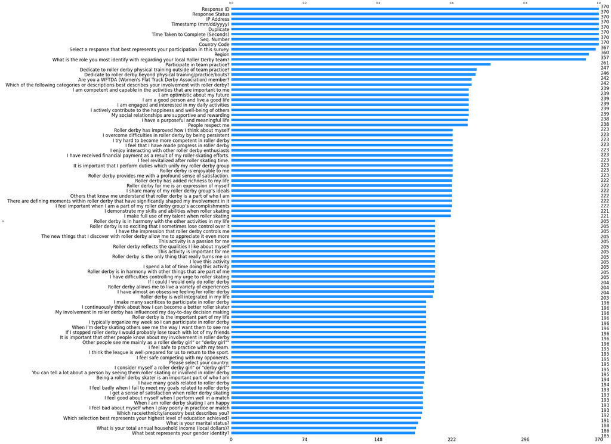

```python
# show data amount of data present for each column
msno.bar(rawData.loc[:, rawData.columns != 'Other'], sort='ascending', color='dodgerblue', fontsize=17)
```

This implies that the further into the survey, the more likely we have NaN values. Likely this means that the participant quit the survey, so the following variables after an NaN value should be NaN as well.

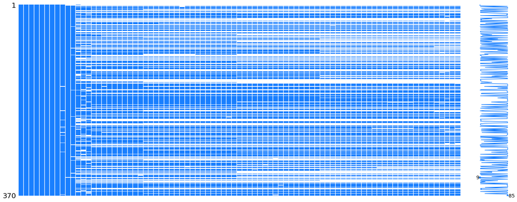

```python
# visualize the data in a tabular manner
msno.matrix(rawData.loc[:, rawData.columns != 'Other'], color=[0.1, 0.5, 1])
```

```python
# number of entries of completed surveys
rawData[rawData['Response Status'] == 'Completed'].shape[0]
```

```
198
```

# Upcoming Challenges

Question variables with an 'Other' option will have a following column for handling text entry when Other is selected. Three questions in the survey have an 'Other' option. Therefore, there are 3 columns labeled as Other.

```python
# show columns with the same name
rawData.loc[:, rawData.columns == 'Other'].head(n=4)
```

|  | Other | Other | Other |
| --- | --- | --- | --- |
| 0 | NaN | NaN | NaN |
| 1 | NaN | NaN | NaN |
| 2 | NaN | NaN | NaN |
| 3 | NaN | NaN | NaN |

Another issue that may need to be addressed is the length of the column names themselves. Some contain over 40 characters, and depending on the amount of data manipulation needed, these names may need to be changed.

```python
rawData.columns
```

```
Index(['Response ID', 'Response Status', 'IP Address',
       'Timestamp (mm/dd/yyyy)', 'Duplicate',
       'Time Taken to Complete (Seconds)', 'Seq. Number', 'Country Code',
       'Region',
       'Select a response that best represents your participation in this survey.',
       'What is the role you most identify with regarding your local Roller Derby team?',
       'Other', 'Participate in team practice?',
       'Dedicate to roller derby physical training outside of team practice?',
       'Dedicate to roller derby beyond physical training/practice/bouts?',
       'Are you a WFTDA (Women's Flat Track Derby Association) member?',
       'Which of the following categories or descriptions best describes your involvement with roller derby?',
       'I have a purposeful and meaningful life',
       'My social relationships are supportive and rewarding',
       'I actively contribute to the happiness and well-being of others',
       'I am competent and capable in the activities that are important to me',
       'I am engaged and interested in my daily activities',
       'I am a good person and live a good life',
       'I am optimistic about my future', 'People respect me',
       'I overcome difficulties in roller derby by being persistent',
       'I try hard to become more competent in roller derby',
       'I feel that I have made progress in roller derby',
       'There are defining moments within roller derby that have significantly shaped my involvement in it',
       'Others that know me understand that roller derby is a part of who I am',
       'I share many of my roller derby group’s ideals',
       'Roller derby has added richness to my life',
       'I make full use of my talent when roller skating',
       'I demonstrate my skills and abilities when roller skating',
       'Roller derby for me is an expression of myself',
       'Roller derby has improved how I think about myself',
       'Roller derby provides me with a profound sense of satisfaction.',
       'Roller derby is enjoyable to me',
       'I feel revitalized after roller skating time.',
       'I have received financial payment as a result of my roller-skating efforts.',
       'I enjoy interacting with other roller derby enthusiasts',
       'I feel important when I am a part of my roller derby group’s accomplishments',
       'It is important that I perform duties which unify my roller derby group',
       'Roller derby is in harmony with the other activities in my life',
       'I have difficulties controlling my urge to roller skating',
       'The new things that I discover with roller derby allow me to appreciate it even more',
       'I have almost an obsessive feeling for roller derby',
```

[output cut: 24 more lines]

```
       'I feel bad about myself when I play poorly in practice or match',
       'I feel badly when I fail to meet my goals related to roller derby',
       'I get a sense of satisfaction when roller derby skating',
       'I feel good about myself when I perform well in a match',
       'When I am roller derby skating I am happy',
       'I feel safe to practice with my team.',
       'I feel safe competing with my opponents.',
       'I think the league is well-prepared for us to return to the sport.',
       'Please select your country:', 'Other',
       'Which race/ethnicity/ancestry best describes you?', 'Other',
       'What is your total annual household income (local dollars)?',
       'What best represents your gender identity?',
       'Which selection best represents your highest level of education achieved?',
       'What is your marital status?'],
      dtype='object', name=0)
```